# Portfolio Investment Assignment

FE8828 AY20/21 Group Assignment

NEE, TSLA, APPL, NVDA, AMD

```r
library(conflicted)
library(tidyverse)
library(lubridate)
library(alphavantager)
library(testit)
library(kableExtra)
conflict_prefer('last', 'dplyr')
```

```
## [conflicted] Will prefer dplyr::last over any other package
```

```r
conflict_prefer('lag', 'dplyr')
```

```
## [conflicted] Will prefer dplyr::lag over any other package
```

```r
conflict_prefer('filter', 'dplyr')
```

```
## [conflicted] Will prefer dplyr::filter over any other package
```

```r
options(dplyr.summarise.inform = FALSE)
```

# Overview

- SPDR sector ETFs: `c('XLB','XLE','XLF','XLI','XLK','XLP','XLU','XLV','XLY')` and `'SPY'`
- History from 1999-11-01 to now.
- Strategy:
  - Equal-weighted with 1) no re-balance, 2) monthly re-balance, 3) annual re-balance
  - Momentum strategy with 1) long top 4, 2) long top 2 and short bottom 2
- Note:
  - All equity position, no cash.
  - Do not load other library, use only the listed packages here.
  - Submit Rmd and Rda data files together in a compressed file (.zip, .7z, etc.)
- Disclaimer: this is no an investment advise.

## Download

```r
# Change (FALSE) to (TRUE), when you need to download data.
# Usually you only need to run this once.
# Change file location

# 'XLC', 'XLRE' has shorter history, don't use them.
all_tickers <- c('XLB','XLE','XLF','XLI','XLK','XLP','XLU','XLV','XLY','SPY')

if (FALSE) {
  av_api_key("")

  for (tt in all_tickers) {
    df_xlc <- av_get(tt, av_fun = "TIME_SERIES_DAILY_ADJUSTED", outputsize="full")
    saveRDS(df_xlc, paste0("E:/Dropbox/MFE/FE8828/2020/notes-2020/example/spdr/",tt,".Rds"))
    cat(paste(tt,min(df_xlc$timestamp),max(df_xlc$timestamp),"\n"))
  }
}
```

## Load and check

```r
# make sure all starts from the same time and same length.
dd <- list()
for (tt in all_tickers) {
  dd[[tt]] <- readRDS(paste0("E:/Dropbox/MFE/FE8828/2020/notes-2020/example/spdr/",tt,".Rds"))
  print(paste(tt, min(dd[[tt]]$timestamp), nrow(dd[[tt]])))
  assert(min(dd[[tt]]$timestamp) == as.Date('1999-11-01'))
  assign(paste0('df_',tolower(tt)), dd[[tt]], envir = .GlobalEnv)
}
```

```
## [1] "XLB 1999-11-01 5265"
## [1] "XLE 1999-11-01 5265"
## [1] "XLF 1999-11-01 5265"
## [1] "XLI 1999-11-01 5265"
## [1] "XLK 1999-11-01 5265"
## [1] "XLP 1999-11-01 5265"
## [1] "XLU 1999-11-01 5265"
## [1] "XLV 1999-11-01 5265"
## [1] "XLY 1999-11-01 5265"
## [1] "SPY 1999-11-01 5265"
```

### Technology vs. Energy

- Energy was the rock star during 90s and 00s, abruptly stopped during GFC on the journey towards $200/bbl (never there).
- Technology was a prodigy from late 70s, stumbled in early 00s, but now a rock star.

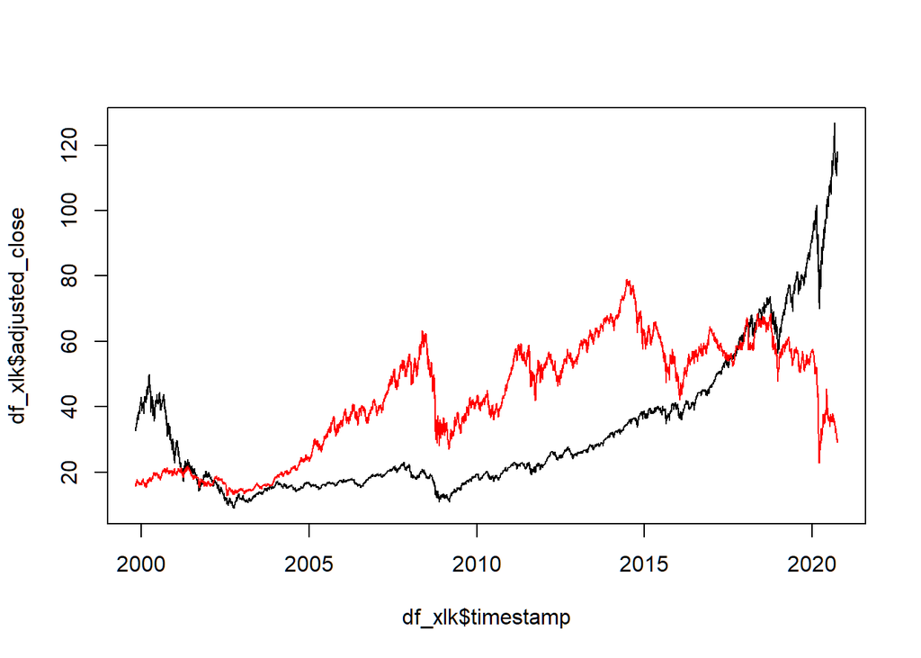

```r
plot(df_xlk$timestamp, df_xlk$adjusted_close,type='l')
points(df_xle$timestamp, df_xle$adjusted_close,col='red',type='l')
```

# Equal-weighted Strategy

## Compute daily return series

```r
len_tickers <- length(all_tickers)
ii <- 1
daily_ret <- tail(tibble(Date = dd[[1]]$timestamp), -1)
for (ii in 1:len_tickers) {
  daily_ret[all_tickers[ii]] <- tail(dd[[ii]]$adjusted_close / lag(dd[[ii]]$adjusted_close, 1)-1,-1)
}
for (ii in 1:len_tickers) {
  daily_ret[paste0(all_tickers[ii],"_cumret")] <- cumprod(1 + daily_ret[all_tickers[ii]])
}
```

## Performance

### Calculate Strategy Return

```r
invest_tickers <- all_tickers[all_tickers != 'SPY']
len_invest <- length(invest_tickers)
w <- rep(1, len_invest) / len_invest
w
```

```
## [1] 0.1111111 0.1111111 0.1111111 0.1111111 0.1111111 0.1111111 0.1111111
## [8] 0.1111111 0.1111111
```

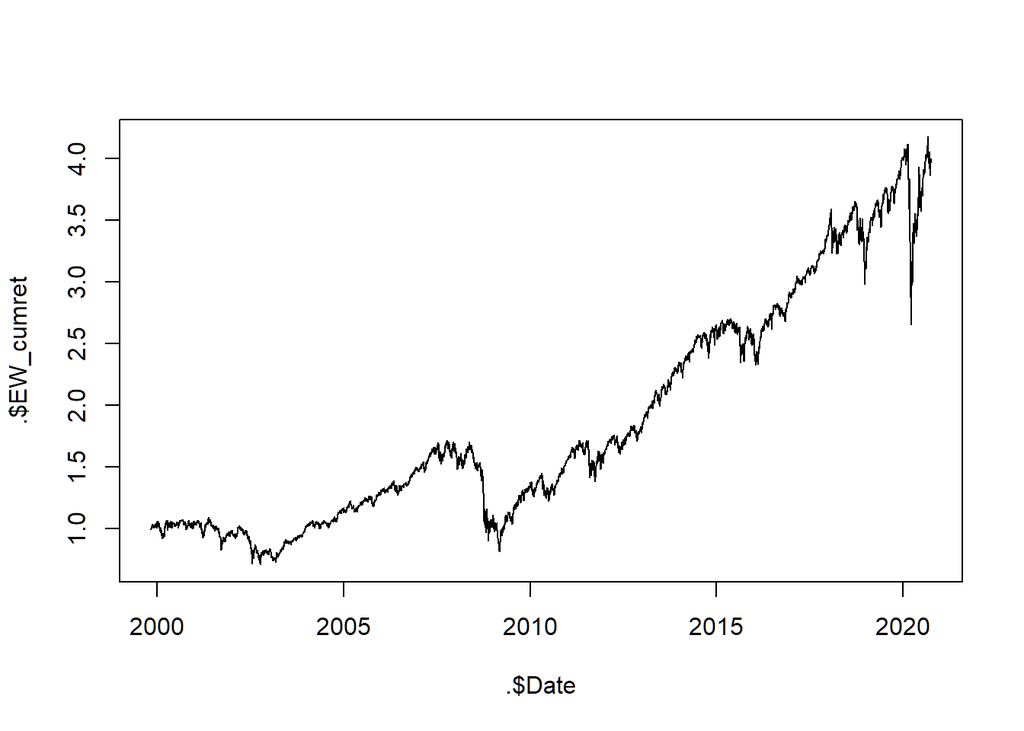

```r
em_cumret <- as.matrix(daily_ret %>% select(XLB_cumret:XLY_cumret)) %*% w
ret_from_cumret <- function(cumret) {
  ret <- cumret / lag(cumret,1) - 1
  ret[1,1] <- cumret[1,1]-1
  ret
}
em_ret <- ret_from_cumret(em_cumret)

daily_ret['EW_cumret'] <- em_cumret
daily_ret['EW_ret'] <- em_ret

daily_ret %>% {plot(.$Date,.$EW_cumret,type='l')}
```

### Relative Performance between EW and SPY

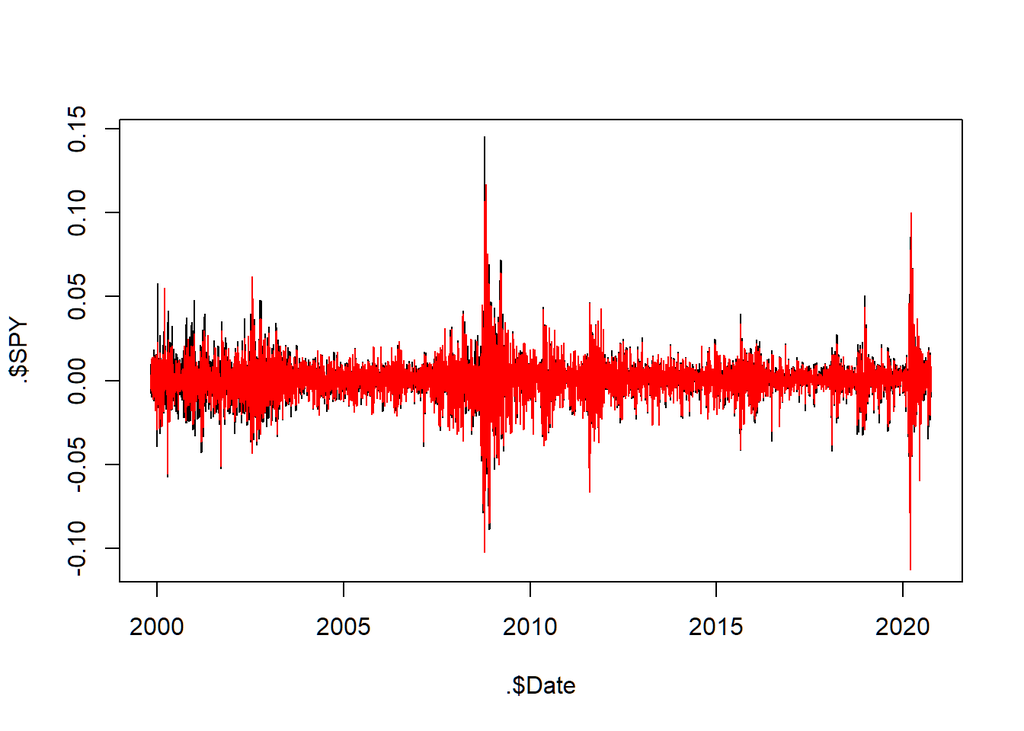

```r
daily_ret %>% {plot(.$Date,.$SPY,type='l'); points(.$Date,.$EW_ret,type='l', col='red'); }
```

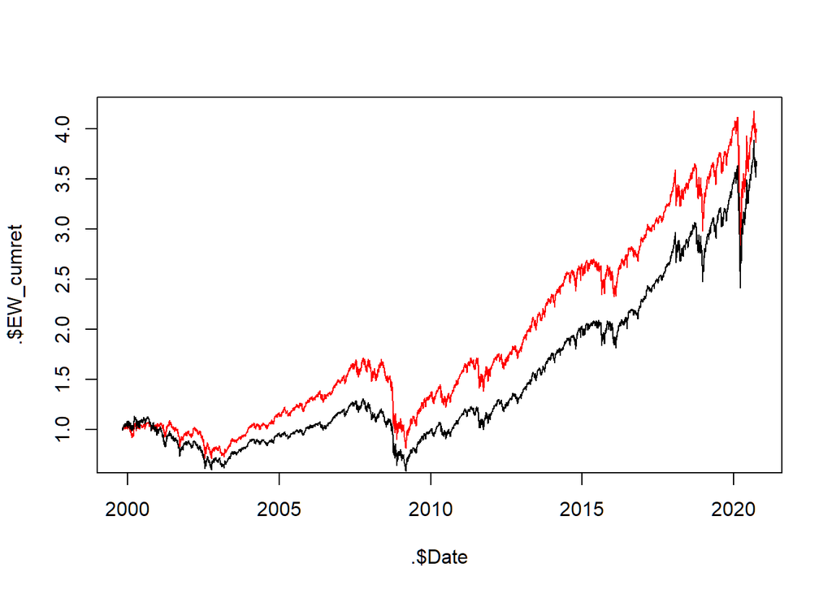

```r
daily_ret %>% {plot(.$Date,.$EW_cumret,type='l',col='red'); points(.$Date,.$SPY_cumret,type='l');}
```

### Metric

```r
# annualized return for EW
prod(daily_ret$EW + 1) ** (250 / length(daily_ret$EW))
```

```
## [1] 1
```

```r
# annualized return for SPY
prod(daily_ret$SPY + 1) ** (250 / length(daily_ret$SPY))
```

```
## [1] 1.063344
```

```r
# simplified Sharp ratio
prod(daily_ret$EW + 1) ** (250 / length(daily_ret$EW)) / sd(daily_ret$EW) / sqrt(250)
```

```
## [1] NA
```

```r
prod(daily_ret$SPY + 1) ** (250 / length(daily_ret$SPY)) / sd(daily_ret$SPY) / sqrt(250)
```

```
## [1] 5.369538
```

```r
# Calculate the Max DD
# maximum_drawdown <- '' in %
```

### Analyze

```r
# Rank all ETFs by its contribution to PnL over the entire period.
# Rank all ETFs by its risk (max. draw down %) over the entire period
```

### Let’s try improve

- Add Re-balance: reset the weights so each ETF has equal market value.

Re-balance is an action to adjust the weights of each stock so each ETF will have equal market value. Without re-balance, one stock can grow its value to a certain extend that reduces the diversification of our investment portfolio.

- The starting allocation for each ETF is 1/9.
- On the next re-balance day, calculate the value of the portfolio. For example, it has grown to 1.3 based on each ETF’s relative return during the previous period.
- The allocation for each ETF becomes 1.3/9.

If we re-balance every day, multiply weights to return everyday

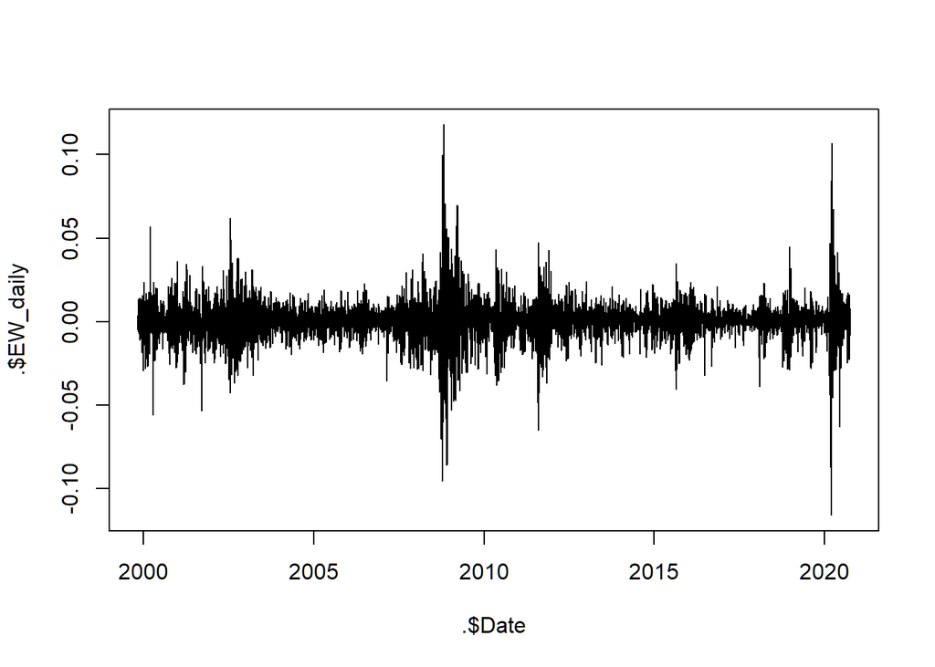

```r
daily_ret['EW_daily'] <- as.matrix(daily_ret %>% select(XLB:XLY)) %*% w
daily_ret %>% {plot(.$Date,.$EW_daily,type='l')}
```

```r
daily_ret['EW_daily_cumret'] <- cumprod(daily_ret['EW_daily'] + 1)

tail(daily_ret['EW_daily_cumret'],1)
```

| EW_daily_cumret |
| --- |
| 4.525439 |

```r
# annualized return for EW_daily
prod(daily_ret$EW_daily + 1) ** (250 / length(daily_ret$EW_daily))
```

```
## [1] 1.074333
```

- If we re-balance less frequently.

Step 1: to calculate re-balance dates so the last re-balance happens on the last day.

rebal_days is the vector of numbers. They are the n-th days on which re-balance is applied. I have written the custom function calc_rebal_days() to help you to obtain the rebal_days vector which always ends at the last day of the downloaded data.

```r
calc_rebal_days <- function(nn, period) {
  rev(nn - (0:(round(nn / period,0) - 1)) * period)
}

# Monthly re-balance
# every 21 days
rebal_days <- calc_rebal_days(length(dd[[1]]$timestamp), 21)
head(rebal_days)
```

```
## [1]  15  36  57  78  99 120
```

```r
# Annual re-balance
# every 252 days
rebal_days <- calc_rebal_days(length(dd[[1]]$timestamp), 252)
head(rebal_days)
```

```
## [1]  225  477  729  981 1233 1485
```

Step 2: generalized code to do re-balance

```r
# 12:20 is where we have stored cumret for each ETF  We will re-write these columns' content.

row_daily_ret <- nrow(daily_ret)

rebal_days <- 1:row_daily_ret
w0 <- w
for (ii in 1:row_daily_ret) {
  if (ii == 1) {
    prev_cumret <- matrix(w0,1,len_invest)
  }
  daily_ret[ii,12:20] <- prev_cumret * as.matrix(1 + daily_ret[ii,2:10])

  if (ii %in% rebal_days) {
    # when re-balance, multiple weights with cumret
    port_sum <- sum(daily_ret[ii,12:20])
    daily_ret[ii,12:20] <- matrix(rep(port_sum, len_invest) / len_invest, 1, len_invest)
  }
  prev_cumret <- as.matrix(daily_ret[ii,12:20])
}

sum(daily_ret[row_daily_ret,12:20])
```

```
## [1] 4.525439
```

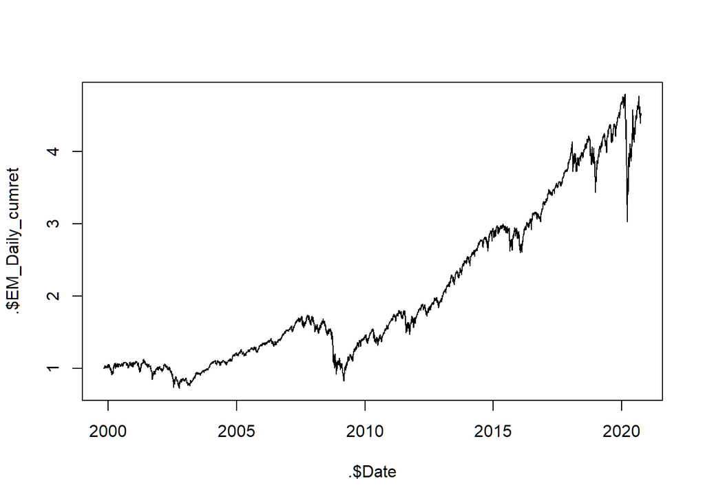

```r
daily_ret['EM_Daily_cumret'] <- rowSums(as.matrix(daily_ret[12:20]))
daily_ret %>% { plot(.$Date, .$EM_Daily_cumret, type='l') }
```

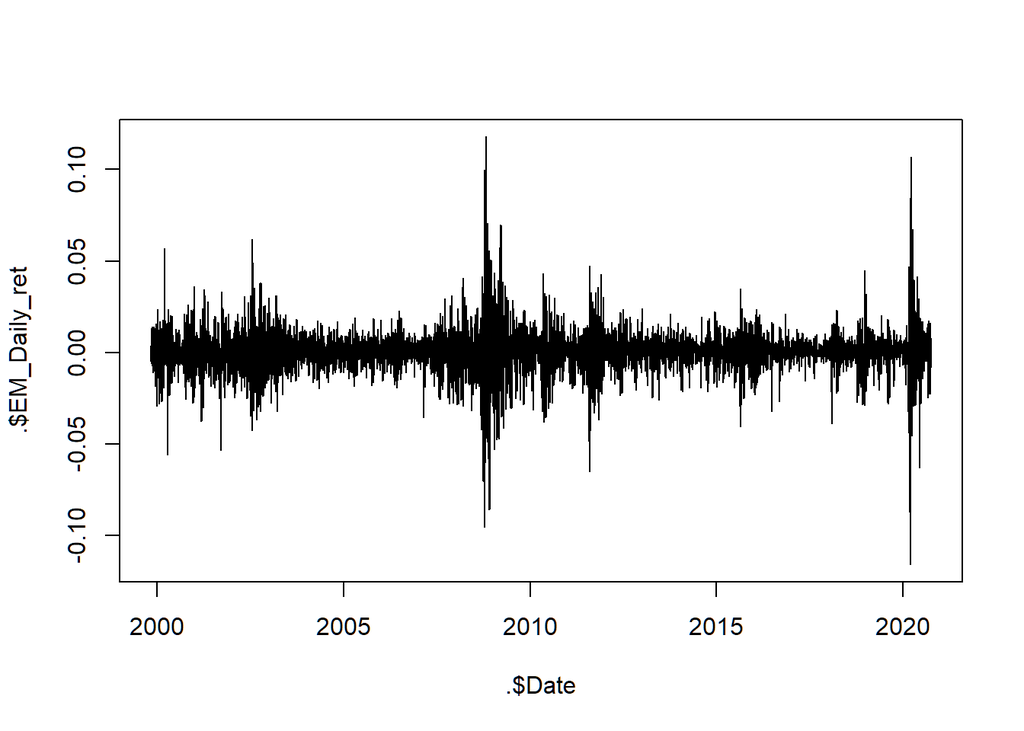

```r
daily_ret['EM_Daily_ret'] <- ret_from_cumret(daily_ret['EM_Daily_cumret'])
daily_ret %>% { plot(.$Date, .$EM_Daily_ret, type='l') }
```

### TODO

For each of 3 EW strategy: + no re-balance + monthly re-balance, and + annually re-balance.

Do the analysis prescribed in the ## Performance section.

# Momentum Strategy

- Empirically, there appears to be certain “inertia” in stock returns known as the momentum effect, whereby future returns are positively correlated with past returns.
- We use a price momentum here. At any point, we rank the ETFs according to following.
  - At row `i`, momentum is `( price[i-21] - price[i-252] ) / price[i-252] - ( price[i-1] - price[i-21] ) / price[i-21]`
- Set to re-balance every month
  1. Long the top 4 stocks with equal weights,
     - Calculate the portfolio value of A, B, C, D on re-balance day. For example, 1.2
     - Allocation is to replace B,D with E,F. Make A,C,E,F has equal weights of 1.2/4 for the next period, or
  2. Long the top 2 stocks and Short bottom 2 stocks with equal weights.
     - Shorting means borrow the stock, sell it and later buy it back to return.
     - Let’s assume the borrow cost is the full value of the stock.
     - It’s still equal weights from the portfolio value, 1/4 each for the top 2 long, and -1/4 each for the bottom 2 shorts.

```r
daily_price <- tibble(Date = dd[[1]]$timestamp)
for (ii in 1:len_tickers) {
  if (all_tickers[ii] == 'SPY') { next }
  daily_price[all_tickers[ii]] <- dd[[ii]]$adjusted_close
}
daily_price
```

| Date | XLB | XLE | XLF | XLI | XLK | XLP | XLU | XLV | XLY |
| --- | --- | --- | --- | --- | --- | --- | --- | --- | --- |
| 1999-11-01 | 14.6397 | 16.6041 | 13.4042 | 18.3863 | 32.8134 | 15.3459 | 14.0502 | 20.6038 | 21.7290 |
| 1999-11-02 | 14.7737 | 16.4505 | 13.3883 | 18.6143 | 32.6665 | 15.0437 | 13.9200 | 20.3406 | 21.5671 |
| 1999-11-03 | 14.7554 | 16.3644 | 13.3299 | 18.4869 | 33.1536 | 15.4322 | 13.7573 | 20.4283 | 21.3898 |
| 1999-11-04 | 14.9443 | 16.1002 | 13.4891 | 18.4332 | 33.4010 | 15.3644 | 13.6875 | 20.6622 | 21.6519 |
| 1999-11-05 | 14.9138 | 15.7069 | 13.8183 | 18.5338 | 33.7644 | 15.4754 | 13.8038 | 20.5672 | 21.7983 |
| 1999-11-08 | 14.7737 | 16.3030 | 13.7439 | 18.5607 | 34.1046 | 15.4569 | 13.8921 | 20.6038 | 21.7290 |
| 1999-11-09 | 14.8285 | 16.6471 | 13.4785 | 18.5741 | 33.7335 | 15.1917 | 13.6875 | 20.4649 | 21.4977 |
| 1999-11-10 | 14.8712 | 17.0158 | 13.2715 | 18.5003 | 34.3211 | 15.1979 | 13.7433 | 20.5891 | 21.5825 |
| 1999-11-11 | 14.7859 | 17.0158 | 13.1972 | 18.5741 | 34.7927 | 15.1979 | 13.7015 | 20.8303 | 21.6288 |
| 1999-11-12 | 14.8285 | 17.1326 | 13.7705 | 18.7015 | 34.9860 | 15.3027 | 13.7433 | 21.2396 | 22.1375 |

[output cut: 5255 more lines]

```r
rebal_days <- calc_rebal_days(nrow(daily_price), 21)
rebal_days
```

```
##   [1]   15   36   57   78   99  120  141  162  183  204  225  246  267  288  309
##  [16]  330  351  372  393  414  435  456  477  498  519  540  561  582  603  624
##  [31]  645  666  687  708  729  750  771  792  813  834  855  876  897  918  939
##  [46]  960  981 1002 1023 1044 1065 1086 1107 1128 1149 1170 1191 1212 1233 1254
##  [61] 1275 1296 1317 1338 1359 1380 1401 1422 1443 1464 1485 1506 1527 1548 1569
##  [76] 1590 1611 1632 1653 1674 1695 1716 1737 1758 1779 1800 1821 1842 1863 1884
##  [91] 1905 1926 1947 1968 1989 2010 2031 2052 2073 2094 2115 2136 2157 2178 2199
## [106] 2220 2241 2262 2283 2304 2325 2346 2367 2388 2409 2430 2451 2472 2493 2514
## [121] 2535 2556 2577 2598 2619 2640 2661 2682 2703 2724 2745 2766 2787 2808 2829
## [136] 2850 2871 2892 2913 2934 2955 2976 2997 3018 3039 3060 3081 3102 3123 3144
## [151] 3165 3186 3207 3228 3249 3270 3291 3312 3333 3354 3375 3396 3417 3438 3459
## [166] 3480 3501 3522 3543 3564 3585 3606 3627 3648 3669 3690 3711 3732 3753 3774
## [181] 3795 3816 3837 3858 3879 3900 3921 3942 3963 3984 4005 4026 4047 4068 4089
## [196] 4110 4131 4152 4173 4194 4215 4236 4257 4278 4299 4320 4341 4362 4383 4404
## [211] 4425 4446 4467 4488 4509 4530 4551 4572 4593 4614 4635 4656 4677 4698 4719
## [226] 4740 4761 4782 4803 4824 4845 4866 4887 4908 4929 4950 4971 4992 5013 5034
## [241] 5055 5076 5097 5118 5139 5160 5181 5202 5223 5244 5265
```

```r
# Assume monthly re-balance
for (r in rebal_days) {
  print(r)
  mm <- numeric(len_invest)

  # Calculate momentum
  # print(mm)
  for (ii in 1:len_invest) {
     tt <- invest_tickers[ii]

     # Use 1 if look-back period is not enough.
     r_prev_d <- if_else(r > 1, r - 1, 1)
     r_prev_m <- if_else(r > 21, r - 21, 1)
     r_prev_y <- if_else(r > 252, r - 252, 1)

     x <- (daily_price[r_prev_m,tt] - daily_price[r_prev_y,tt] ) / daily_price[r_prev_y,tt] - ( daily_price[r_prev_d,tt] - daily_price[r_prev_m,tt] ) / daily_price[r_prev_m,tt]

     mm[ii] <- as.numeric(x)
  }
  # TODO: rank and allocation.
  # print(mm)
  # run one cycle first, then remove break
  break
}
```

```
## [1] 15
```

```r
mm
```

```
## [1] -0.03245285 -0.07327708 -0.02890885 -0.05691194 -0.11003736 -0.01165784
## [7]  0.02846223 -0.04469564 -0.02057159
```

### TODO

For each of 2 Momentum strategies (Both are monthly re-balanced): - Long the top 4 stocks with equal weights, or - Long the top 2 stocks and Short bottom 2 stocks with equal weights.

Do the analysis prescribed in the ## Performance section.

- Note: there is lead-in period *exclude* the lead-in period when Momentum strategy still wait for more data.
  - For both momentum strategy portfolio and S&P in comparison, you need to exlcude the lead-in period so as to start from the first rebal_day day.